# GB Search Task (E1) OPAM Analyses

Dave Braun

08/10/2022

This document was last updated at 2022-08-16 14:58:11.

The big effects of interest:

- Quadrant bias
- Line orientation bias

```r
d <- read.csv('../../data/exp1_long_data.csv')
thinnest_lines <- read.csv('../../data/thinnest_lines.csv')
line_data <- read.csv('../../data/exp1_line_data.csv')
head(d)
```

|  | participant | date | overall_time | trial_count | click_order | prompt_rt_sec | selection_rt_ms | pressed_object | line_width | top_x | top_y | bottom_x | bottom_y | line_id | line_orientation | selected_or_released | accuracy | possible_thinnest_lines | is_practice | drop_marker | indecision_trial | accuracy_type |
| --- | --- | --- | --- | --- | --- | --- | --- | --- | --- | --- | --- | --- | --- | --- | --- | --- | --- | --- | --- | --- | --- | --- |
| 1 | 10 | 2021_Oct_01_1059 | 0 days 00:31:04.465510000 | 2 | 1 | 18.06451 | 980.533 | line | 1.3333 | -204.59657 | -99.34668 | -302.29828 | -169.02003 | r2c0_bottom_right | forward_slash | selected | NA | 3 | False | 10_2 | 0 | hit |
| 2 | 10 | 2021_Oct_01_1059 | 0 days 00:31:05.332162000 | 2 | 2 | 18.06451 | 1847.185 | line | 1.3333 | -204.59657 | 280.00000 | -302.29828 | 210.32666 | r0c0_bottom_right | forward_slash | selected | NA | 3 | False | 10_2 | 0 | hit |
| 3 | 10 | 2021_Oct_01_1059 | 0 days 00:31:06.467754000 | 2 | 3 | 18.06451 | 2982.777 | line | 1.0000 | 283.91202 | 210.32666 | 283.91202 | 90.32666 | r1c2_right | vertical | selected | NA | 3 | False | 10_2 | 0 | hit |
| 4 | 10 | 2021_Oct_01_1059 | 0 days 00:31:08.071316000 | 2 | 4 | 18.06451 | 4586.339 | submit | NA | NA | NA | NA | NA |  |  |  | 1 | 3 | False | 10_2 | 0 | NA |
| 5 | 10 | 2021_Oct_01_1059 | 0 days 00:31:59.290233000 | 4 | 1 | 10.26303 | 499.617 | line | 1.0000 | 88.50858 | 210.32666 | 88.50858 | 90.32666 | r1c1_right | vertical | selected | NA | 4 | False | 10_4 | 0 | hit |
| 6 | 10 | 2021_Oct_01_1059 | 0 days 00:32:00.722075000 | 4 | 2 | 10.26303 | 1931.459 | line | 1.0000 | -204.59657 | 280.00000 | -106.89485 | 210.32666 | r0c1_bottom_left | back_slash | selected | NA | 4 | False | 10_4 | 0 | hit |

```r
N <- length(unique(d$participant))
```

**There were 31 participants in this study.**

```r
source('../compute_accuracy_columns.r')

result <- compute_accuracy_columns(d, thinnest_lines)
d <- result[[1]]
thinnest_lines <- result[[2]]
```

```r
## a function for spot checking accuracy coding throughout the data
spot_check <- function() {
  participant <- sample(d$participant, size = 1)
  trial <- sample(d[d$participant==participant,]$trial_count, size = 1)
  d_sub <- d[d$participant == participant & d$trial_count == trial,]
  t_sub <- thinnest_lines[thinnest_lines$participant == participant & thinnest_lines$trial_count == trial,]
  print('Subset of long data:')
  print(d_sub[,c('line_id', 'selected_or_released', 'accuracy_type')])
  print(' ')
  print(' ')
  print('Subset of thinnest lines data:')
  print(t_sub[,c('line_width', 'line_id', 'accuracy_type')])
}
## Anything coded as a "hit" in the long data should be represented in the thinnest lines data
## Anything coded as a "false alarm" shouldn't be represented in the thinnest lines data
spot_check()
```

```
## [1] "Subset of long data:"
##                line_id selected_or_released accuracy_type
## 1351  r1c0_bottom_left             selected           hit
## 1352  r0c2_bottom_left             selected           hit
## 1353 r0c2_bottom_right             selected           hit
## 1354                                                 <NA>
## [1] " "
## [1] " "
## [1] "Subset of thinnest lines data:"
##      line_width           line_id accuracy_type
## 1329     1.0000  r0c2_bottom_left           hit
## 1330     1.0000 r0c2_bottom_right           hit
## 1331     1.3333  r1c0_bottom_left           hit
```

```r
## summarize hits and false alarms
summary_data <- d %>%
  filter(!(is.na(accuracy_type))) %>%
  mutate(hit = ifelse(accuracy_type == 'hit', 1, 0), false_alarm = ifelse(accuracy_type == 'false_alarm', 1, 0)) %>%
  group_by(participant, line_orientation) %>%
  summarize(hits = sum(hit), false_alarms = sum(false_alarm))
```

Base rate of line orientation types on each trial:

```r
line_data %>%
  filter(participant == 10, trial_count == 2) %>%
  group_by(line_orientation) %>%
  summarize(count = n())
```

| line_orientation | count |
| --- | --- |
| back_slash | 22 |
| forward_slash | 21 |
| vertical | 20 |

```r
## summarize misses
summary_data_p <- thinnest_lines %>%
  filter(accuracy_type == 'miss') %>%
  group_by(participant, line_orientation) %>%
  summarize(miss_count = n()) %>%
  inner_join(summary_data) %>%
  gather(accuracy_type, count, miss_count:false_alarms)
summary_data <- summary_data_p %>%
  group_by(line_orientation, accuracy_type) %>%
  summarize(m = mean(count), se = sd(count) / sqrt(N))
```

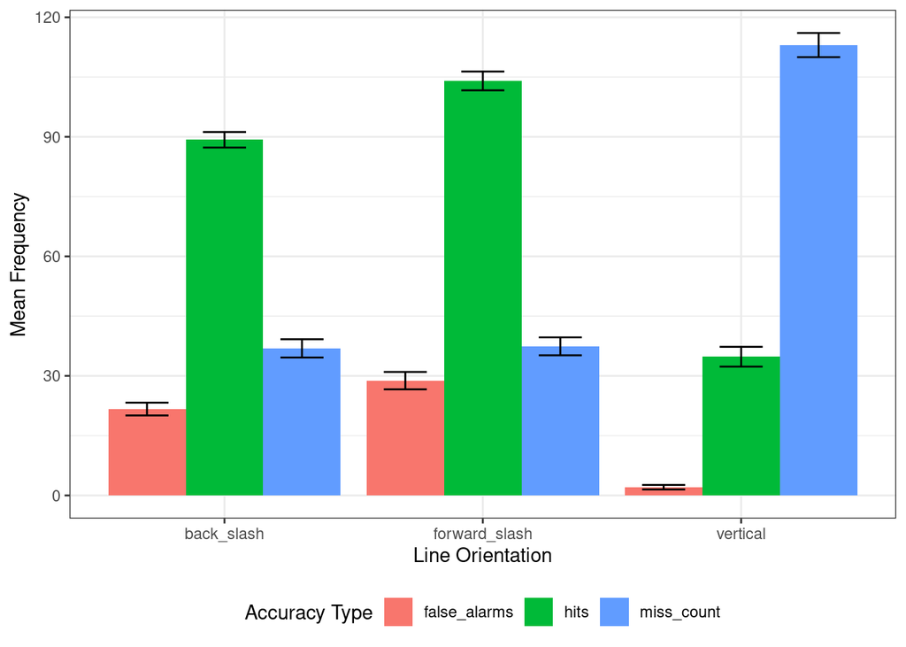

```r
## export in long format so they can work with it for the poster
write.csv(summary_data_p, 'line_orientation.csv', row.names = FALSE)

## broken down by accuracy type
summary_data %>%
  ggplot(aes(x = line_orientation, y = m)) +
  geom_bar(stat = 'identity', aes(fill = accuracy_type), position = position_dodge(width = .9)) +
  geom_errorbar(aes(ymin = m - se, ymax = m + se, group = accuracy_type), position = position_dodge(width = .9), width = .5) +
  labs(
    y = 'Mean Frequency',
    x = 'Line Orientation',
    fill = 'Accuracy Type'
  ) +
  theme_bw() +
  theme(legend.position = 'bottom')
```

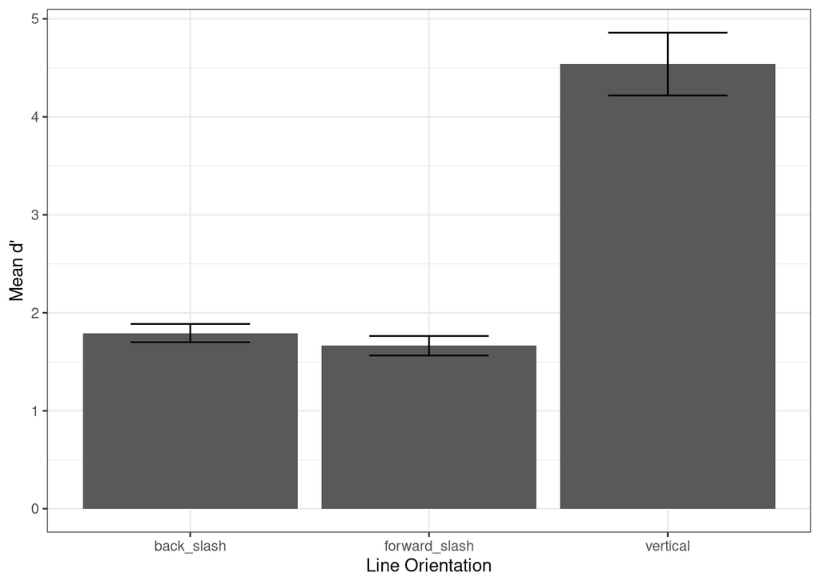

```r
d %>%
  filter(!is.na(accuracy_type)) %>%
  group_by(participant, line_orientation, accuracy_type) %>%
  summarize(count = n()) %>%
  spread(accuracy_type, count) %>%
  mutate(hit = ifelse(is.na(hit), 0, hit), false_alarm = ifelse(is.na(false_alarm), 0, false_alarm)) %>%
  mutate(hit_rate = hit / (hit + false_alarm)) %>%
  mutate(hit_rate = min(.999, hit_rate)) %>%
  mutate(fa_rate = 1 - hit_rate) %>%
  mutate(d_prime = qnorm(hit_rate) - qnorm(fa_rate)) %>%
  group_by(line_orientation) %>%
  summarize(dp_mean = mean(d_prime), se = sd(d_prime) / sqrt(N)) %>%
  ggplot(aes(x = line_orientation, y = dp_mean)) +
  geom_bar(stat = 'identity') +
  geom_errorbar(aes(ymin = dp_mean - se, ymax = dp_mean + se), width = .5) +
  labs(
    x = 'Line Orientation',
    y = "Mean d'"
  ) +
  theme_bw()
```

```r
ggsave('line_orientation.png', height = 1080 / 300, width = 1920 / 300, units = 'in', dpi = 300)
```

~ *left off here* ~

## Quadrant Analysis

We’ll calculate the center of the grid by looking at the most extreme X’s and Y’s and taking the center, then compare the center of the lines against that center point.

```r
line_data <- read.csv('../../data/exp1_line_data.csv')
head(line_data)
```

|  | participant | date | trial_count | line_id | line_width | is_exterior | top_x | top_y | bottom_x | bottom_y | line_orientation | drop_marker |
| --- | --- | --- | --- | --- | --- | --- | --- | --- | --- | --- | --- | --- |
| 1 | 10 | 2021_Oct_01_1059 | 2 | r0c0_left | 2.333333 | True | -400.0000 | 400.0000 | -400.0000 | 280.0000 | vertical | 10_2 |
| 2 | 10 | 2021_Oct_01_1059 | 2 | r0c0_bottom_left | 2.333333 | True | -400.0000 | 280.0000 | -302.2983 | 210.3267 | back_slash | 10_2 |
| 3 | 10 | 2021_Oct_01_1059 | 2 | r0c0_bottom_right | 1.333300 | False | -204.5966 | 280.0000 | -302.2983 | 210.3267 | forward_slash | 10_2 |
| 4 | 10 | 2021_Oct_01_1059 | 2 | r0c0_right | 3.333300 | False | -204.5966 | 400.0000 | -204.5966 | 280.0000 | vertical | 10_2 |
| 5 | 10 | 2021_Oct_01_1059 | 2 | r0c0_top_right | 2.333333 | True | -302.2983 | 469.6733 | -204.5966 | 400.0000 | back_slash | 10_2 |
| 6 | 10 | 2021_Oct_01_1059 | 2 | r0c0_top_left | 2.333333 | True | -302.2983 | 469.6733 | -400.0000 | 400.0000 | forward_slash | 10_2 |

```r
top_left <- c(min(line_data$top_x), max(line_data$top_y))
top_right <- c(max(line_data$top_x), max(line_data$top_y))
bottom_left <- c(min(line_data$bottom_x), min(line_data$bottom_y))
bottom_right <- c(max(line_data$bottom_x), min(line_data$bottom_y))
print(top_left)
```

```
## [1] -400.0000  469.6733
```

```r
print(top_right)
```

```
## [1] 479.3154 469.6733
```

```r
print(bottom_left)
```

```
## [1] -400.0000 -358.6934
```

```r
print(bottom_right)
```

```
## [1]  479.3154 -358.6934
```

```r
center <- c(mean(c(top_left[1], top_right[1])), mean(c(top_left[2], bottom_left[2])))
center
```

```
## [1] 39.65772 55.48999
```

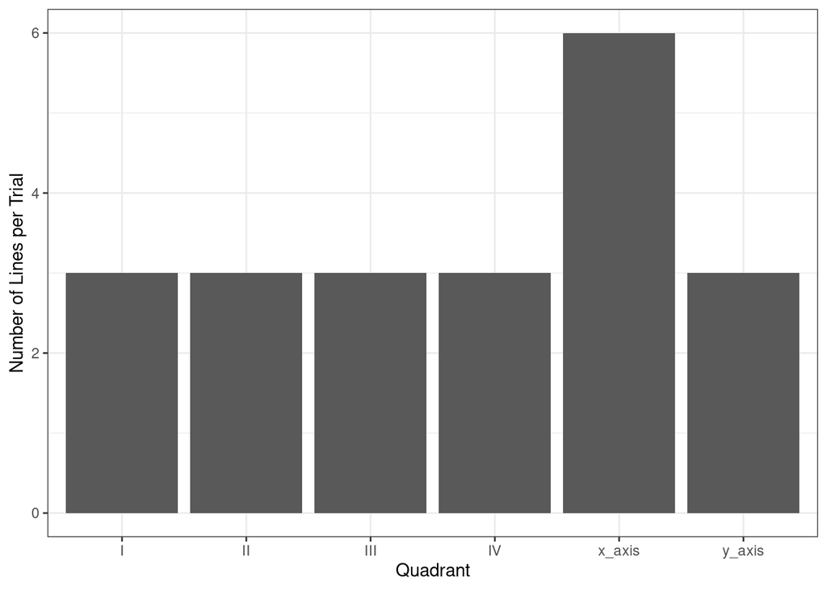

```r
source('../compute_quadrants.r')
## calculate line centers

d <- d %>%
  mutate(line_center_x = (top_x + bottom_x) / 2, line_center_y = (top_y + bottom_y) / 2) %>%
  mutate(quadrant = ifelse(line_center_x > center[1] & line_center_y > center[2], 'I', ifelse(line_center_x < center[1] & line_center_y > center[2], 'II',
                    ifelse(line_center_x < center[1] & line_center_y < center[2], 'III', ifelse(line_center_x > center[1] & line_center_y < center[2], 'IV', '')))))
line_data <- line_data %>%
  mutate(line_center_x = (top_x + bottom_x) / 2, line_center_y = (top_y + bottom_y) / 2) %>%
  mutate(quadrant = ifelse(line_center_x > center[1] & line_center_y > center[2], 'I', ifelse(line_center_x < center[1] & line_center_y > center[2], 'II',
                    ifelse(line_center_x < center[1] & line_center_y < center[2], 'III', ifelse(line_center_x > center[1] & line_center_y < center[2], 'IV', '')))))

## append line coordinates to thinnest lines data (for including misses in summarization)

line_data %>%
  filter(participant == 1, trial_count == 0, is_exterior == 'False', line_orientation != 'vertical') %>%
  mutate(x_dist = abs(line_center_x - center[1]), y_dist = abs(line_center_y - center[2])) %>%
  mutate(is_on_axis = ifelse(x_dist < 0.1, 'y_axis', ifelse(y_dist < 0.1, 'x_axis', ''))) %>%
  mutate(quadrant = ifelse(is_on_axis == '', quadrant, is_on_axis)) %>%
  group_by(quadrant) %>%
  summarize(count = n()) %>%
  ggplot(aes(x = quadrant, y = count)) +
  geom_bar(stat = 'identity') +
  labs(
    x = 'Quadrant',
    y = 'Number of Lines per Trial'
  ) +
  theme_bw()
```

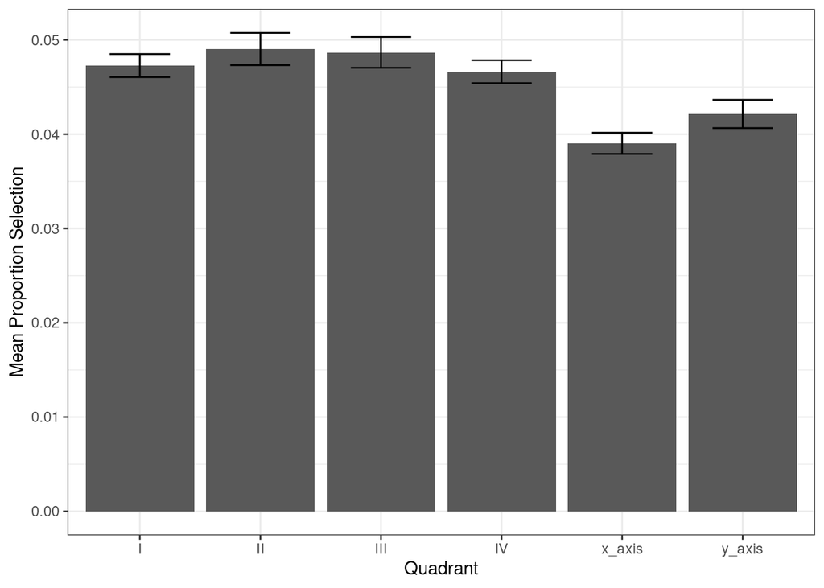

```r
ggsave('lines_per_quadrant.png', height = 1080 / 300, width = 1920 / 300, units = 'in', dpi = 300)

d <- d %>%
  mutate(x_dist = abs(line_center_x - center[1]), y_dist = abs(line_center_y - center[2])) %>%
  mutate(is_on_axis = ifelse(x_dist < 0.1, 'y_axis', ifelse(y_dist < 0.1, 'x_axis', ''))) %>%
  mutate(quadrant = ifelse(is_on_axis == '', quadrant, is_on_axis))

d %>%
  filter(!(is.na(quadrant)), !(is.na(accuracy_type))) %>%
  group_by(participant, quadrant) %>%
  summarize(count = n()) %>%
  ## im not sure whether this makes sense
  mutate(proportion = ifelse(quadrant == 'x_axis', count / (6*300), count / (3*300))) %>%
  group_by(quadrant) %>%
  ## add in SEs
  summarize(mean_proportion = mean(proportion), se = sd(proportion) / sqrt(N)) %>%
  ggplot(aes(x = quadrant, y = mean_proportion)) +
  geom_bar(stat = 'identity') +
  geom_errorbar(aes(ymin = mean_proportion - se, ymax = mean_proportion + se), width = .5) +
  labs(
    x = 'Quadrant',
    y = 'Mean Proportion Selection'
  ) +
  theme_bw()
```

```r
ggsave('selection_by_quadrant.png', height = 1080 / 300, width = 1920 / 300, units = 'in', dpi = 300)
```

The proportion selection across quadrants would suggest that Ps *under* sampled from the x_axis, but I just have trouble trusting this metric because the max proportion for x_axis is 0.5 and the max for everything else is 1.

The way proportion selection is being calculated is as `number of selected lines in quadrant / total number of lines in the quadrant * total number of line selections (300)`.

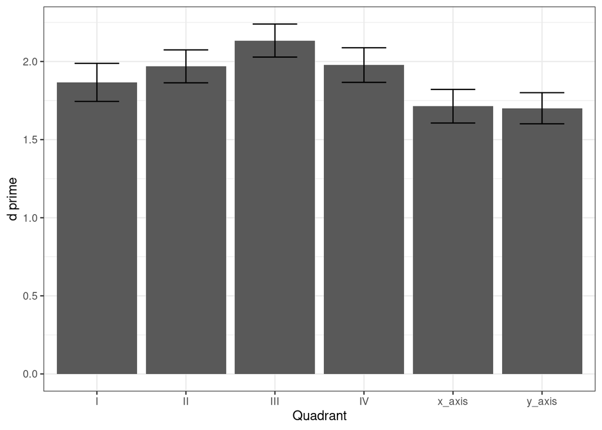

```r
d %>%
  filter(!(is.na(quadrant)), !(is.na(top_x)), !(is.na(accuracy_type))) %>%
  group_by(participant, quadrant, accuracy_type) %>%
  summarize(count = n()) %>%
  spread(accuracy_type, count) %>%
  mutate(hit_rate = hit / (hit + false_alarm)) %>%
  mutate(d_prime = qnorm(hit_rate) - qnorm(1 - hit_rate)) %>%
  group_by(quadrant) %>%
  summarize(mean_dprime = mean(d_prime), se = sd(d_prime) / sqrt(N)) %>%
  ggplot(aes(x = quadrant, y = mean_dprime)) +
  geom_bar(stat = 'identity', position = position_dodge(width = .9)) +
  geom_errorbar(aes(ymin = mean_dprime - se, ymax = mean_dprime + se), width = .5, position = position_dodge(.9)) +
  labs(
    x = 'Quadrant',
    y = 'd prime'
  ) +
  theme_bw() +
  theme(legend.position = 'bottom')
```

```r
ggsave('accuracy_by_quadrant.png', height = 1080 / 300, width = 1920 / 300, units = 'in', dpi = 300)
```

d prime was calculated at the subject level for each quadrant by first calculating hit rate per quadrant as `hit_rate = hits / (hits + false_alarms)`, `falsealarm_rate = 1 - hit_rate`, and d prime as `d_prime = qnorm(hit_rate) - qnorm(falsealarm_rate)`, and then averaging d prime across subjects.

I’m not sure that my way of calculating hit rate was the best. It’s pretty difficult to think about what the denominator for any proportion should be in this paradigm because, for example, accuracy is defined at the level of each line and not at the overall trial level.

A work by [Dave Braun](https://davebraun.net)

*dab414@lehigh.edu*